# Risk Factor Analysis

## Outcome Variable

**Outcome Variable:** sstunted

## Predictor Variables

**Intervention Variable:** parity

**Adjustment Set:**

unadjusted

## Stratifying Variables

The analysis was stratified on these variable(s):

- agecat
- studyid
- country

## Data Summary

| agecat | studyid | country | parity | sstunted | n_cell | n |
| --- | --- | --- | --- | --- | --- | --- |
| Birth | COHORTS | GUATEMALA | 1 | 0 | 109 | 852 |
| Birth | COHORTS | GUATEMALA | 1 | 1 | 3 | 852 |
| Birth | COHORTS | GUATEMALA | 2 | 0 | 134 | 852 |
| Birth | COHORTS | GUATEMALA | 2 | 1 | 3 | 852 |
| Birth | COHORTS | GUATEMALA | 3+ | 0 | 598 | 852 |
| Birth | COHORTS | GUATEMALA | 3+ | 1 | 5 | 852 |
| Birth | COHORTS | INDIA | 1 | 0 | 674 | 4122 |
| Birth | COHORTS | INDIA | 1 | 1 | 22 | 4122 |
| Birth | COHORTS | INDIA | 2 | 0 | 1016 | 4122 |
| Birth | COHORTS | INDIA | 2 | 1 | 21 | 4122 |
| Birth | COHORTS | INDIA | 3+ | 0 | 2319 | 4122 |
| Birth | COHORTS | INDIA | 3+ | 1 | 70 | 4122 |
| Birth | COHORTS | PHILIPPINES | 1 | 0 | 661 | 3050 |
| Birth | COHORTS | PHILIPPINES | 1 | 1 | 14 | 3050 |
| Birth | COHORTS | PHILIPPINES | 2 | 0 | 677 | 3050 |
| Birth | COHORTS | PHILIPPINES | 2 | 1 | 10 | 3050 |
| Birth | COHORTS | PHILIPPINES | 3+ | 0 | 1666 | 3050 |
| Birth | COHORTS | PHILIPPINES | 3+ | 1 | 22 | 3050 |
| Birth | GMS-Nepal | NEPAL | 1 | 0 | 196 | 696 |
| Birth | GMS-Nepal | NEPAL | 1 | 1 | 15 | 696 |
| Birth | GMS-Nepal | NEPAL | 2 | 0 | 175 | 696 |
| Birth | GMS-Nepal | NEPAL | 2 | 1 | 5 | 696 |
| Birth | GMS-Nepal | NEPAL | 3+ | 0 | 294 | 696 |
| Birth | GMS-Nepal | NEPAL | 3+ | 1 | 11 | 696 |
| Birth | JiVitA-3 | BANGLADESH | 1 | 0 | 6332 | 22455 |
| Birth | JiVitA-3 | BANGLADESH | 1 | 1 | 1124 | 22455 |
| Birth | JiVitA-3 | BANGLADESH | 2 | 0 | 6940 | 22455 |
| Birth | JiVitA-3 | BANGLADESH | 2 | 1 | 675 | 22455 |
| Birth | JiVitA-3 | BANGLADESH | 3+ | 0 | 6735 | 22455 |
| Birth | JiVitA-3 | BANGLADESH | 3+ | 1 | 649 | 22455 |

[output cut: 144 more lines]

The following strata were considered:

- agecat: 24 months, studyid: COHORTS, country: GUATEMALA
- agecat: 24 months, studyid: COHORTS, country: INDIA
- agecat: 24 months, studyid: COHORTS, country: PHILIPPINES
- agecat: 24 months, studyid: GMS-Nepal, country: NEPAL
- agecat: 24 months, studyid: JiVitA-3, country: BANGLADESH
- agecat: 24 months, studyid: Keneba, country: GAMBIA
- agecat: 24 months, studyid: PROVIDE, country: BANGLADESH
- agecat: 24 months, studyid: TanzaniaChild2, country: TANZANIA, UNITED REPUBLIC OF
- agecat: 24 months, studyid: ZVITAMBO, country: ZIMBABWE
- agecat: 6 months, studyid: COHORTS, country: GUATEMALA
- agecat: 6 months, studyid: COHORTS, country: INDIA
- agecat: 6 months, studyid: COHORTS, country: PHILIPPINES
- agecat: 6 months, studyid: GMS-Nepal, country: NEPAL
- agecat: 6 months, studyid: JiVitA-3, country: BANGLADESH
- agecat: 6 months, studyid: Keneba, country: GAMBIA
- agecat: 6 months, studyid: PROVIDE, country: BANGLADESH
- agecat: 6 months, studyid: SAS-CompFeed, country: INDIA
- agecat: 6 months, studyid: SAS-FoodSuppl, country: INDIA
- agecat: 6 months, studyid: TanzaniaChild2, country: TANZANIA, UNITED REPUBLIC OF
- agecat: 6 months, studyid: ZVITAMBO, country: ZIMBABWE
- agecat: Birth, studyid: COHORTS, country: GUATEMALA
- agecat: Birth, studyid: COHORTS, country: INDIA
- agecat: Birth, studyid: COHORTS, country: PHILIPPINES
- agecat: Birth, studyid: GMS-Nepal, country: NEPAL
- agecat: Birth, studyid: JiVitA-3, country: BANGLADESH
- agecat: Birth, studyid: Keneba, country: GAMBIA
- agecat: Birth, studyid: PROVIDE, country: BANGLADESH
- agecat: Birth, studyid: SAS-CompFeed, country: INDIA
- agecat: Birth, studyid: ZVITAMBO, country: ZIMBABWE

### Dropped Strata

Some strata were dropped due to rare outcomes:

- agecat: Birth, studyid: COHORTS, country: GUATEMALA
- agecat: Birth, studyid: Keneba, country: GAMBIA
- agecat: Birth, studyid: PROVIDE, country: BANGLADESH
- agecat: 6 months, studyid: Keneba, country: GAMBIA
- agecat: 6 months, studyid: PROVIDE, country: BANGLADESH
- agecat: 6 months, studyid: SAS-FoodSuppl, country: INDIA
- agecat: 6 months, studyid: TanzaniaChild2, country: TANZANIA, UNITED REPUBLIC OF
- agecat: 24 months, studyid: TanzaniaChild2, country: TANZANIA, UNITED REPUBLIC OF

## Methods Detail

We’re interested in the causal parameters $E[Y_a]$ for all values of $a \in \mathcal{A}$. These parameters represent the mean outcome if, possibly contrary to fact, we intervened to set all units to have $A=a$. Under the randomization and positivity assumptions, these are identified by the statistical parameters $\psi_a=E_W[E_{Y|A,W}(Y|A=a,W)]$. In addition, we’re interested in the mean of $Y$, $E[Y]$ under no intervention (the observed mean). We will estimate these parameters by using SuperLearner to fit the relevant likelihood factors – $E_{Y|A,W}(Y|A=a,W)$ and $p(A=a|W)$, and then updating our likelihood fit using a joint TMLE.

For unadjusted analyses ($W=\{\}$), initial likelihoods were estimated using Lrnr_glm to estimate the simple $E(Y|A)$ and Lrnr_mean to estimate $p(A)$. For adjusted analyses, a small library containing Lrnr_glmnet, Lrnr_xgboost, and Lrnr_mean was used.

Having estimated these parameters, we will then use the delta method to estimate relative risks and attributable risks relative to a prespecified baseline level of $A$.

# Results Detail

## Results Plots

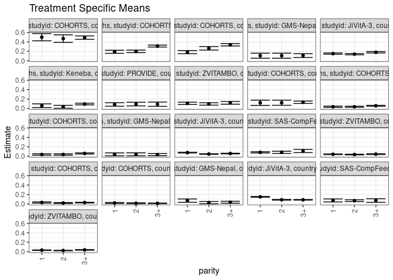

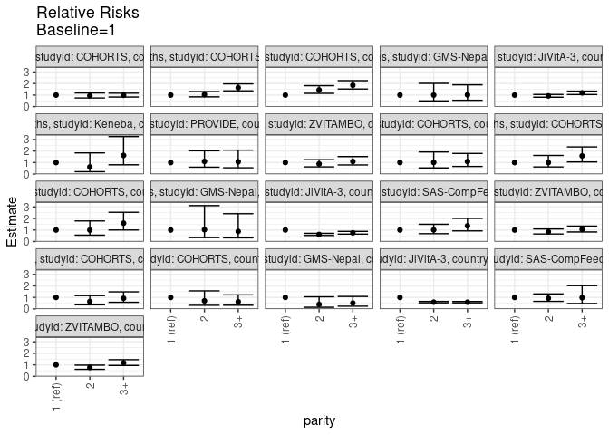

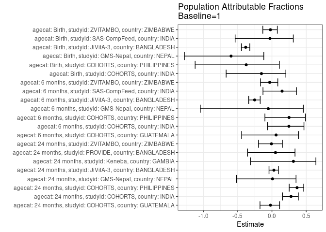

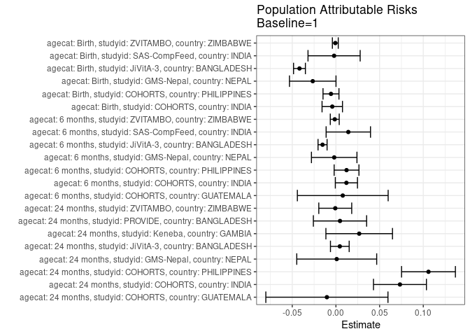

## Results Table

### Parameter: TSM

| agecat | studyid | country | intervention_level | baseline_level | estimate | ci_lower | ci_upper |
| --- | --- | --- | --- | --- | --- | --- | --- |
| Birth | COHORTS | INDIA | 1 | NA | 0.0316092 | 0.0186096 | 0.0446087 |
| Birth | COHORTS | INDIA | 2 | NA | 0.0202507 | 0.0116766 | 0.0288248 |
| Birth | COHORTS | INDIA | 3+ | NA | 0.0293010 | 0.0225374 | 0.0360645 |
| Birth | COHORTS | PHILIPPINES | 1 | NA | 0.0207407 | 0.0099878 | 0.0314937 |
| Birth | COHORTS | PHILIPPINES | 2 | NA | 0.0145560 | 0.0055987 | 0.0235134 |
| Birth | COHORTS | PHILIPPINES | 3+ | NA | 0.0130332 | 0.0076218 | 0.0184446 |
| Birth | GMS-Nepal | NEPAL | 1 | NA | 0.0710900 | 0.0363916 | 0.1057885 |
| Birth | GMS-Nepal | NEPAL | 2 | NA | 0.0277778 | 0.0037532 | 0.0518023 |
| Birth | GMS-Nepal | NEPAL | 3+ | NA | 0.0360656 | 0.0151254 | 0.0570058 |
| Birth | JiVitA-3 | BANGLADESH | 1 | NA | 0.1507511 | 0.1419200 | 0.1595821 |
| Birth | JiVitA-3 | BANGLADESH | 2 | NA | 0.0886408 | 0.0812408 | 0.0960409 |
| Birth | JiVitA-3 | BANGLADESH | 3+ | NA | 0.0878927 | 0.0813717 | 0.0944138 |
| Birth | SAS-CompFeed | INDIA | 1 | NA | 0.0747922 | 0.0429611 | 0.1066234 |
| Birth | SAS-CompFeed | INDIA | 2 | NA | 0.0692042 | 0.0504516 | 0.0879567 |
| Birth | SAS-CompFeed | INDIA | 3+ | NA | 0.0730897 | 0.0353975 | 0.1107819 |
| Birth | ZVITAMBO | ZIMBABWE | 1 | NA | 0.0325597 | 0.0280646 | 0.0370548 |
| Birth | ZVITAMBO | ZIMBABWE | 2 | NA | 0.0250965 | 0.0203340 | 0.0298591 |
| Birth | ZVITAMBO | ZIMBABWE | 3+ | NA | 0.0382251 | 0.0320807 | 0.0443695 |
| 6 months | COHORTS | GUATEMALA | 1 | NA | 0.1212121 | 0.0655061 | 0.1769182 |
| 6 months | COHORTS | GUATEMALA | 2 | NA | 0.1223022 | 0.0678072 | 0.1767971 |
| 6 months | COHORTS | GUATEMALA | 3+ | NA | 0.1318841 | 0.1066240 | 0.1571441 |
| 6 months | COHORTS | INDIA | 1 | NA | 0.0364865 | 0.0229758 | 0.0499972 |
| 6 months | COHORTS | INDIA | 2 | NA | 0.0364964 | 0.0253932 | 0.0475995 |
| 6 months | COHORTS | INDIA | 3+ | NA | 0.0574338 | 0.0482290 | 0.0666386 |
| 6 months | COHORTS | PHILIPPINES | 1 | NA | 0.0365854 | 0.0212239 | 0.0519468 |
| 6 months | COHORTS | PHILIPPINES | 2 | NA | 0.0363036 | 0.0214087 | 0.0511985 |
| 6 months | COHORTS | PHILIPPINES | 3+ | NA | 0.0582461 | 0.0465007 | 0.0699915 |
| 6 months | GMS-Nepal | NEPAL | 1 | NA | 0.0392157 | 0.0084313 | 0.0700001 |
| 6 months | GMS-Nepal | NEPAL | 2 | NA | 0.0402685 | 0.0086750 | 0.0718620 |
| 6 months | GMS-Nepal | NEPAL | 3+ | NA | 0.0343511 | 0.0122781 | 0.0564242 |
| 6 months | JiVitA-3 | BANGLADESH | 1 | NA | 0.0759850 | 0.0689686 | 0.0830014 |
| 6 months | JiVitA-3 | BANGLADESH | 2 | NA | 0.0464912 | 0.0410638 | 0.0519187 |
| 6 months | JiVitA-3 | BANGLADESH | 3+ | NA | 0.0570520 | 0.0499469 | 0.0641570 |
| 6 months | SAS-CompFeed | INDIA | 1 | NA | 0.0816327 | 0.0684211 | 0.0948442 |
| 6 months | SAS-CompFeed | INDIA | 2 | NA | 0.0822368 | 0.0588631 | 0.1056106 |
| 6 months | SAS-CompFeed | INDIA | 3+ | NA | 0.1109375 | 0.0771916 | 0.1446834 |
| 6 months | ZVITAMBO | ZIMBABWE | 1 | NA | 0.0418350 | 0.0351692 | 0.0485007 |
| 6 months | ZVITAMBO | ZIMBABWE | 2 | NA | 0.0352540 | 0.0282160 | 0.0422919 |
| 6 months | ZVITAMBO | ZIMBABWE | 3+ | NA | 0.0440718 | 0.0361265 | 0.0520170 |
| 24 months | COHORTS | GUATEMALA | 1 | NA | 0.5000000 | 0.4239029 | 0.5760971 |
| 24 months | COHORTS | GUATEMALA | 2 | NA | 0.4701987 | 0.3905532 | 0.5498441 |
| 24 months | COHORTS | GUATEMALA | 3+ | NA | 0.4912985 | 0.4554314 | 0.5271656 |
| 24 months | COHORTS | INDIA | 1 | NA | 0.1897163 | 0.1573537 | 0.2220789 |
| 24 months | COHORTS | INDIA | 2 | NA | 0.1992925 | 0.1724021 | 0.2261828 |
| 24 months | COHORTS | INDIA | 3+ | NA | 0.3114837 | 0.2910205 | 0.3319470 |
| 24 months | COHORTS | PHILIPPINES | 1 | NA | 0.1832061 | 0.1500779 | 0.2163343 |
| 24 months | COHORTS | PHILIPPINES | 2 | NA | 0.2647059 | 0.2276250 | 0.3017867 |
| 24 months | COHORTS | PHILIPPINES | 3+ | NA | 0.3391431 | 0.3141330 | 0.3641531 |
| 24 months | GMS-Nepal | NEPAL | 1 | NA | 0.1076923 | 0.0543500 | 0.1610346 |
| 24 months | GMS-Nepal | NEPAL | 2 | NA | 0.1076923 | 0.0543500 | 0.1610346 |
| 24 months | GMS-Nepal | NEPAL | 3+ | NA | 0.1096491 | 0.0690507 | 0.1502476 |
| 24 months | JiVitA-3 | BANGLADESH | 1 | NA | 0.1515916 | 0.1373893 | 0.1657938 |
| 24 months | JiVitA-3 | BANGLADESH | 2 | NA | 0.1402668 | 0.1266521 | 0.1538816 |
| 24 months | JiVitA-3 | BANGLADESH | 3+ | NA | 0.1798107 | 0.1649145 | 0.1947070 |
| 24 months | Keneba | GAMBIA | 1 | NA | 0.0583942 | 0.0191148 | 0.0976736 |
| 24 months | Keneba | GAMBIA | 2 | NA | 0.0359712 | 0.0050027 | 0.0669398 |
| 24 months | Keneba | GAMBIA | 3+ | NA | 0.0945455 | 0.0772488 | 0.1118422 |
| 24 months | PROVIDE | BANGLADESH | 1 | NA | 0.0853081 | 0.0475843 | 0.1230318 |
| 24 months | PROVIDE | BANGLADESH | 2 | NA | 0.0938967 | 0.0546911 | 0.1331023 |
| 24 months | PROVIDE | BANGLADESH | 3+ | NA | 0.0909091 | 0.0454657 | 0.1363525 |
| 24 months | ZVITAMBO | ZIMBABWE | 1 | NA | 0.1093750 | 0.0851872 | 0.1335628 |
| 24 months | ZVITAMBO | ZIMBABWE | 2 | NA | 0.0966469 | 0.0709193 | 0.1223746 |
| 24 months | ZVITAMBO | ZIMBABWE | 3+ | NA | 0.1199187 | 0.0912041 | 0.1486333 |

### Parameter: E(Y)

| agecat | studyid | country | intervention_level | baseline_level | estimate | ci_lower | ci_upper |
| --- | --- | --- | --- | --- | --- | --- | --- |
| Birth | COHORTS | INDIA | NA | NA | 0.0274139 | 0.0224285 | 0.0323992 |
| Birth | COHORTS | PHILIPPINES | NA | NA | 0.0150820 | 0.0107558 | 0.0194081 |
| Birth | GMS-Nepal | NEPAL | NA | NA | 0.0445402 | 0.0292033 | 0.0598771 |
| Birth | JiVitA-3 | BANGLADESH | NA | NA | 0.1090180 | 0.1044666 | 0.1135695 |
| Birth | SAS-CompFeed | INDIA | NA | NA | 0.0726837 | 0.0523147 | 0.0930527 |
| Birth | ZVITAMBO | ZIMBABWE | NA | NA | 0.0318582 | 0.0289357 | 0.0347806 |
| 6 months | COHORTS | GUATEMALA | NA | NA | 0.1290323 | 0.1078261 | 0.1502384 |
| 6 months | COHORTS | INDIA | NA | NA | 0.0484735 | 0.0420469 | 0.0549002 |
| 6 months | COHORTS | PHILIPPINES | NA | NA | 0.0487445 | 0.0406327 | 0.0568562 |
| 6 months | GMS-Nepal | NEPAL | NA | NA | 0.0372340 | 0.0215945 | 0.0528736 |
| 6 months | JiVitA-3 | BANGLADESH | NA | NA | 0.0606746 | 0.0568229 | 0.0645262 |
| 6 months | SAS-CompFeed | INDIA | NA | NA | 0.0958084 | 0.0774939 | 0.1141229 |
| 6 months | ZVITAMBO | ZIMBABWE | NA | NA | 0.0404938 | 0.0363439 | 0.0446436 |
| 24 months | COHORTS | GUATEMALA | NA | NA | 0.4896617 | 0.4596107 | 0.5197126 |
| 24 months | COHORTS | INDIA | NA | NA | 0.2630178 | 0.2481729 | 0.2778626 |
| 24 months | COHORTS | PHILIPPINES | NA | NA | 0.2891616 | 0.2711872 | 0.3071359 |
| 24 months | GMS-Nepal | NEPAL | NA | NA | 0.1086066 | 0.0809724 | 0.1362407 |
| 24 months | JiVitA-3 | BANGLADESH | NA | NA | 0.1560473 | 0.1472898 | 0.1648047 |
| 24 months | Keneba | GAMBIA | NA | NA | 0.0850291 | 0.0702861 | 0.0997720 |
| 24 months | PROVIDE | BANGLADESH | NA | NA | 0.0899654 | 0.0666186 | 0.1133122 |
| 24 months | ZVITAMBO | ZIMBABWE | NA | NA | 0.1086028 | 0.0935351 | 0.1236705 |

### Parameter: RR

| agecat | studyid | country | intervention_level | baseline_level | estimate | ci_lower | ci_upper |
| --- | --- | --- | --- | --- | --- | --- | --- |
| Birth | COHORTS | INDIA | 1 | 1 | 1.0000000 | 1.0000000 | 1.0000000 |
| Birth | COHORTS | INDIA | 2 | 1 | 0.6406592 | 0.3550449 | 1.1560348 |
| Birth | COHORTS | INDIA | 3+ | 1 | 0.9269759 | 0.5784298 | 1.4855465 |
| Birth | COHORTS | PHILIPPINES | 1 | 1 | 1.0000000 | 1.0000000 | 1.0000000 |
| Birth | COHORTS | PHILIPPINES | 2 | 1 | 0.7018091 | 0.3138795 | 1.5691883 |
| Birth | COHORTS | PHILIPPINES | 3+ | 1 | 0.6283852 | 0.3234162 | 1.2209285 |
| Birth | GMS-Nepal | NEPAL | 1 | 1 | 1.0000000 | 1.0000000 | 1.0000000 |
| Birth | GMS-Nepal | NEPAL | 2 | 1 | 0.3907407 | 0.1447400 | 1.0548458 |
| Birth | GMS-Nepal | NEPAL | 3+ | 1 | 0.5073224 | 0.2376100 | 1.0831868 |
| Birth | JiVitA-3 | BANGLADESH | 1 | 1 | 1.0000000 | 1.0000000 | 1.0000000 |
| Birth | JiVitA-3 | BANGLADESH | 2 | 1 | 0.5879948 | 0.5322514 | 0.6495761 |
| Birth | JiVitA-3 | BANGLADESH | 3+ | 1 | 0.5830323 | 0.5296248 | 0.6418253 |
| Birth | SAS-CompFeed | INDIA | 1 | 1 | 1.0000000 | 1.0000000 | 1.0000000 |
| Birth | SAS-CompFeed | INDIA | 2 | 1 | 0.9252851 | 0.6568848 | 1.3033527 |
| Birth | SAS-CompFeed | INDIA | 3+ | 1 | 0.9772364 | 0.4726236 | 2.0206164 |
| Birth | ZVITAMBO | ZIMBABWE | 1 | 1 | 1.0000000 | 1.0000000 | 1.0000000 |
| Birth | ZVITAMBO | ZIMBABWE | 2 | 1 | 0.7707851 | 0.6095582 | 0.9746562 |
| Birth | ZVITAMBO | ZIMBABWE | 3+ | 1 | 1.1739998 | 0.9498273 | 1.4510803 |
| 6 months | COHORTS | GUATEMALA | 1 | 1 | 1.0000000 | 1.0000000 | 1.0000000 |
| 6 months | COHORTS | GUATEMALA | 2 | 1 | 1.0089928 | 0.5319730 | 1.9137559 |
| 6 months | COHORTS | GUATEMALA | 3+ | 1 | 1.0880435 | 0.6613262 | 1.7900979 |
| 6 months | COHORTS | INDIA | 1 | 1 | 1.0000000 | 1.0000000 | 1.0000000 |
| 6 months | COHORTS | INDIA | 2 | 1 | 1.0002703 | 0.6194218 | 1.6152817 |
| 6 months | COHORTS | INDIA | 3+ | 1 | 1.5741118 | 1.0514846 | 2.3565043 |
| 6 months | COHORTS | PHILIPPINES | 1 | 1 | 1.0000000 | 1.0000000 | 1.0000000 |
| 6 months | COHORTS | PHILIPPINES | 2 | 1 | 0.9922992 | 0.5516806 | 1.7848331 |
| 6 months | COHORTS | PHILIPPINES | 3+ | 1 | 1.5920593 | 0.9992361 | 2.5365907 |
| 6 months | GMS-Nepal | NEPAL | 1 | 1 | 1.0000000 | 1.0000000 | 1.0000000 |
| 6 months | GMS-Nepal | NEPAL | 2 | 1 | 1.0268456 | 0.3384548 | 3.1153701 |
| 6 months | GMS-Nepal | NEPAL | 3+ | 1 | 0.8759542 | 0.3176197 | 2.4157685 |
| 6 months | JiVitA-3 | BANGLADESH | 1 | 1 | 1.0000000 | 1.0000000 | 1.0000000 |
| 6 months | JiVitA-3 | BANGLADESH | 2 | 1 | 0.6118475 | 0.5279594 | 0.7090647 |
| 6 months | JiVitA-3 | BANGLADESH | 3+ | 1 | 0.7508320 | 0.6420062 | 0.8781047 |
| 6 months | SAS-CompFeed | INDIA | 1 | 1 | 1.0000000 | 1.0000000 | 1.0000000 |
| 6 months | SAS-CompFeed | INDIA | 2 | 1 | 1.0074013 | 0.6792562 | 1.4940715 |
| 6 months | SAS-CompFeed | INDIA | 3+ | 1 | 1.3589844 | 0.9192262 | 2.0091230 |
| 6 months | ZVITAMBO | ZIMBABWE | 1 | 1 | 1.0000000 | 1.0000000 | 1.0000000 |
| 6 months | ZVITAMBO | ZIMBABWE | 2 | 1 | 0.8426917 | 0.6527384 | 1.0879233 |
| 6 months | ZVITAMBO | ZIMBABWE | 3+ | 1 | 1.0534671 | 0.8281899 | 1.3400224 |
| 24 months | COHORTS | GUATEMALA | 1 | 1 | 1.0000000 | 1.0000000 | 1.0000000 |
| 24 months | COHORTS | GUATEMALA | 2 | 1 | 0.9403974 | 0.7488851 | 1.1808849 |
| 24 months | COHORTS | GUATEMALA | 3+ | 1 | 0.9825971 | 0.8299796 | 1.1632780 |
| 24 months | COHORTS | INDIA | 1 | 1 | 1.0000000 | 1.0000000 | 1.0000000 |
| 24 months | COHORTS | INDIA | 2 | 1 | 1.0504761 | 0.8451397 | 1.3057014 |
| 24 months | COHORTS | INDIA | 3+ | 1 | 1.6418395 | 1.3675484 | 1.9711456 |
| 24 months | COHORTS | PHILIPPINES | 1 | 1 | 1.0000000 | 1.0000000 | 1.0000000 |
| 24 months | COHORTS | PHILIPPINES | 2 | 1 | 1.4448529 | 1.1494344 | 1.8161976 |
| 24 months | COHORTS | PHILIPPINES | 3+ | 1 | 1.8511559 | 1.5227626 | 2.2503692 |
| 24 months | GMS-Nepal | NEPAL | 1 | 1 | 1.0000000 | 1.0000000 | 1.0000000 |
| 24 months | GMS-Nepal | NEPAL | 2 | 1 | 1.0000000 | 0.4963421 | 2.0147393 |
| 24 months | GMS-Nepal | NEPAL | 3+ | 1 | 1.0181704 | 0.5485894 | 1.8897029 |
| 24 months | JiVitA-3 | BANGLADESH | 1 | 1 | 1.0000000 | 1.0000000 | 1.0000000 |
| 24 months | JiVitA-3 | BANGLADESH | 2 | 1 | 0.9252946 | 0.8132415 | 1.0527870 |
| 24 months | JiVitA-3 | BANGLADESH | 3+ | 1 | 1.1861527 | 1.0485512 | 1.3418115 |
| 24 months | Keneba | GAMBIA | 1 | 1 | 1.0000000 | 1.0000000 | 1.0000000 |
| 24 months | Keneba | GAMBIA | 2 | 1 | 0.6160072 | 0.2065843 | 1.8368521 |
| 24 months | Keneba | GAMBIA | 3+ | 1 | 1.6190909 | 0.8063563 | 3.2509887 |
| 24 months | PROVIDE | BANGLADESH | 1 | 1 | 1.0000000 | 1.0000000 | 1.0000000 |
| 24 months | PROVIDE | BANGLADESH | 2 | 1 | 1.1006781 | 0.5991422 | 2.0220447 |
| 24 months | PROVIDE | BANGLADESH | 3+ | 1 | 1.0656566 | 0.5467246 | 2.0771408 |
| 24 months | ZVITAMBO | ZIMBABWE | 1 | 1 | 1.0000000 | 1.0000000 | 1.0000000 |
| 24 months | ZVITAMBO | ZIMBABWE | 2 | 1 | 0.8836292 | 0.6251308 | 1.2490196 |
| 24 months | ZVITAMBO | ZIMBABWE | 3+ | 1 | 1.0963995 | 0.7914280 | 1.5188899 |

### Parameter: PAR

| agecat | studyid | country | intervention_level | baseline_level | estimate | ci_lower | ci_upper |
| --- | --- | --- | --- | --- | --- | --- | --- |
| Birth | COHORTS | INDIA | 1 | NA | -0.0041953 | -0.0158904 | 0.0074997 |
| Birth | COHORTS | PHILIPPINES | 1 | NA | -0.0056588 | -0.0147781 | 0.0034606 |
| Birth | GMS-Nepal | NEPAL | 1 | NA | -0.0265498 | -0.0531807 | 0.0000811 |
| Birth | JiVitA-3 | BANGLADESH | 1 | NA | -0.0417330 | -0.0485124 | -0.0349536 |
| Birth | SAS-CompFeed | INDIA | 1 | NA | -0.0021085 | -0.0319667 | 0.0277496 |
| Birth | ZVITAMBO | ZIMBABWE | 1 | NA | -0.0007015 | -0.0040634 | 0.0026603 |
| 6 months | COHORTS | GUATEMALA | 1 | NA | 0.0078201 | -0.0441451 | 0.0597853 |
| 6 months | COHORTS | INDIA | 1 | NA | 0.0119871 | -0.0006968 | 0.0246710 |
| 6 months | COHORTS | PHILIPPINES | 1 | NA | 0.0121591 | -0.0020444 | 0.0263626 |
| 6 months | GMS-Nepal | NEPAL | 1 | NA | -0.0019816 | -0.0280222 | 0.0240589 |
| 6 months | JiVitA-3 | BANGLADESH | 1 | NA | -0.0153104 | -0.0204865 | -0.0101344 |
| 6 months | SAS-CompFeed | INDIA | 1 | NA | 0.0141757 | -0.0112232 | 0.0395746 |
| 6 months | ZVITAMBO | ZIMBABWE | 1 | NA | -0.0013412 | -0.0064520 | 0.0037696 |
| 24 months | COHORTS | GUATEMALA | 1 | NA | -0.0103383 | -0.0802450 | 0.0595683 |
| 24 months | COHORTS | INDIA | 1 | NA | 0.0733014 | 0.0429999 | 0.1036030 |
| 24 months | COHORTS | PHILIPPINES | 1 | NA | 0.1059554 | 0.0751311 | 0.1367798 |
| 24 months | GMS-Nepal | NEPAL | 1 | NA | 0.0009142 | -0.0448357 | 0.0466642 |
| 24 months | JiVitA-3 | BANGLADESH | 1 | NA | 0.0044557 | -0.0062603 | 0.0151717 |
| 24 months | Keneba | GAMBIA | 1 | NA | 0.0266349 | -0.0114833 | 0.0647531 |
| 24 months | PROVIDE | BANGLADESH | 1 | NA | 0.0046573 | -0.0258247 | 0.0351394 |
| 24 months | ZVITAMBO | ZIMBABWE | 1 | NA | -0.0007722 | -0.0196185 | 0.0180741 |

### Parameter: PAF

| agecat | studyid | country | intervention_level | baseline_level | estimate | ci_lower | ci_upper |
| --- | --- | --- | --- | --- | --- | --- | --- |
| Birth | COHORTS | INDIA | 1 | NA | -0.1530363 | -0.6680434 | 0.2029627 |
| Birth | COHORTS | PHILIPPINES | 1 | NA | -0.3752013 | -1.1203069 | 0.1080637 |
| Birth | GMS-Nepal | NEPAL | 1 | NA | -0.5960862 | -1.2770413 | -0.1187725 |
| Birth | JiVitA-3 | BANGLADESH | 1 | NA | -0.3828086 | -0.4454919 | -0.3228434 |
| Birth | SAS-CompFeed | INDIA | 1 | NA | -0.0290098 | -0.5369336 | 0.3110561 |
| Birth | ZVITAMBO | ZIMBABWE | 1 | NA | -0.0220208 | -0.1331657 | 0.0782227 |
| 6 months | COHORTS | GUATEMALA | 1 | NA | 0.0606061 | -0.4420966 | 0.3880708 |
| 6 months | COHORTS | INDIA | 1 | NA | 0.2472908 | -0.0629283 | 0.4669715 |
| 6 months | COHORTS | PHILIPPINES | 1 | NA | 0.2494457 | -0.1025563 | 0.4890676 |
| 6 months | GMS-Nepal | NEPAL | 1 | NA | -0.0532213 | -1.0453620 | 0.4576632 |
| 6 months | JiVitA-3 | BANGLADESH | 1 | NA | -0.2523369 | -0.3389442 | -0.1713317 |
| 6 months | SAS-CompFeed | INDIA | 1 | NA | 0.1479592 | -0.1305950 | 0.3578836 |
| 6 months | ZVITAMBO | ZIMBABWE | 1 | NA | -0.0331211 | -0.1673182 | 0.0856485 |
| 24 months | COHORTS | GUATEMALA | 1 | NA | -0.0211132 | -0.1743470 | 0.1121259 |
| 24 months | COHORTS | INDIA | 1 | NA | 0.2786939 | 0.1543886 | 0.3847262 |
| 24 months | COHORTS | PHILIPPINES | 1 | NA | 0.3664230 | 0.2517330 | 0.4635340 |
| 24 months | GMS-Nepal | NEPAL | 1 | NA | 0.0084180 | -0.5164359 | 0.3516146 |
| 24 months | JiVitA-3 | BANGLADESH | 1 | NA | 0.0285536 | -0.0427166 | 0.0949524 |
| 24 months | Keneba | GAMBIA | 1 | NA | 0.3132447 | -0.3136430 | 0.6409734 |
| 24 months | PROVIDE | BANGLADESH | 1 | NA | 0.0517681 | -0.3551785 | 0.3365127 |
| 24 months | ZVITAMBO | ZIMBABWE | 1 | NA | -0.0071103 | -0.1964898 | 0.1522944 |